# Modeling and prediction for movies

## Setup

### Load packages

```r
library(ggplot2)
library(dplyr)
library(statsr)
library(GGally)
library(DAAG)
library(devtools)
```

### Load data

Make sure your data and R Markdown files are in the same directory. When loaded your data file will be called `movies`. Delete this note when before you submit your work.

```r
load("movies.Rdata")
```

## Part 1: Data

This is an observational study which uses a random sample of movies. Since there is no random assignment, this means we can only make generalisable inferences (not causal). This allows us to find associations between variables in the study.

## Part 2: Research question

**Q: How is the imdb rating of a movie associated with measures of the movie’s poplarity, audience rating and critic rating?**

Therefore, the response variable is the “imdb rating”, and the explanatory variables are those linked to either the type of movie it is or the popularity of the movie.

This could be of interest to production houses or producers who would like to know the key factors that drive the imdb rating of movies. How they differ across different genre types (i.e. science fiction). FUrther, it might also be useful for anybody who is creating a movie and it’s expected level of success.

## Part 3: Exploratory data analysis

Given below is a list of variables for the model, either representing movie popularity or type, broken down into categorical or numerical types:

**Numerical:**

- runtime
- imdb_rating (response variable)
- imdb_num_votes
- critics_score
- audience_score

**Categorical:**

- title_type
- genre
- mpaa_rating
- critics rating
- audience_rating
- best_pic_nom
- best_pic_win

Other variables supplied in the data that were not linked to how the movie can be categorised, or how popular the movie was, were excluded For example: release dates; previous actor/director, and not movie, awards; URLs; movie title etc.

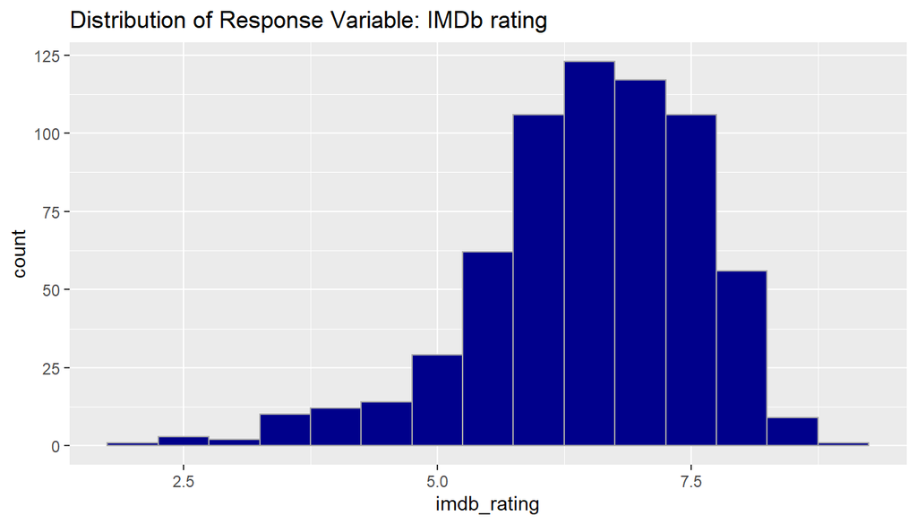

```r
ggplot(data = movies, aes(x = imdb_rating)) +
  geom_histogram(binwidth = .5, color='darkgray', fill  = 'darkblue') +
  labs(title = "Distribution of Response Variable: IMDb rating" )
```

```r
summary(movies$imdb_rating)
```

```
##    Min. 1st Qu.  Median    Mean 3rd Qu.    Max.
##   1.900   5.900   6.600   6.493   7.300   9.000
```

Next, we will check how the other numerical variables are related, looking specifically at the correlation values using a pairwise plot:

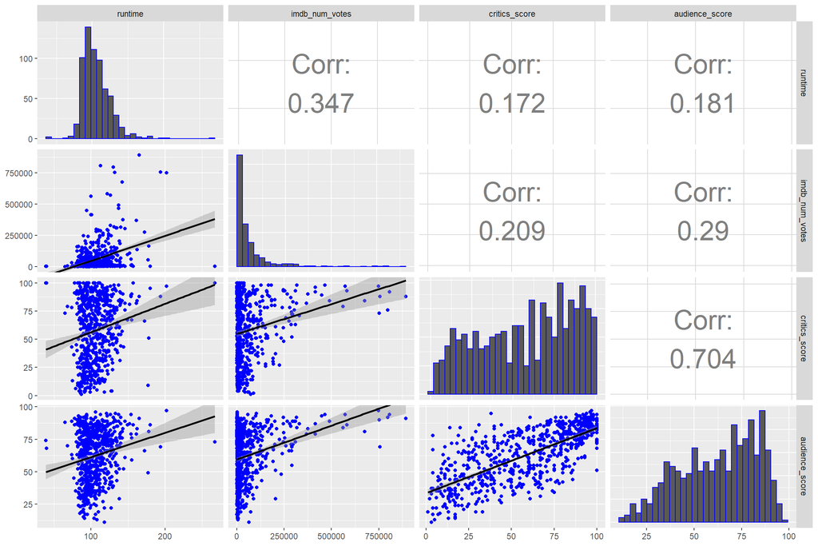

```r
num_cols <- c(4,14,16,18)
ggpairs(movies,
        columns = num_cols,
        upper = list(continuous = wrap("cor", size = 10)),
        diag = list(continuous = wrap("barDiag", colour = "blue")),
        lower = list(continuous = wrap("smooth", colour = 'blue')))
```

Next, since the variable imdb_num_votes was not strongly correlated with the other variables, we will look at the distribution of this variable:

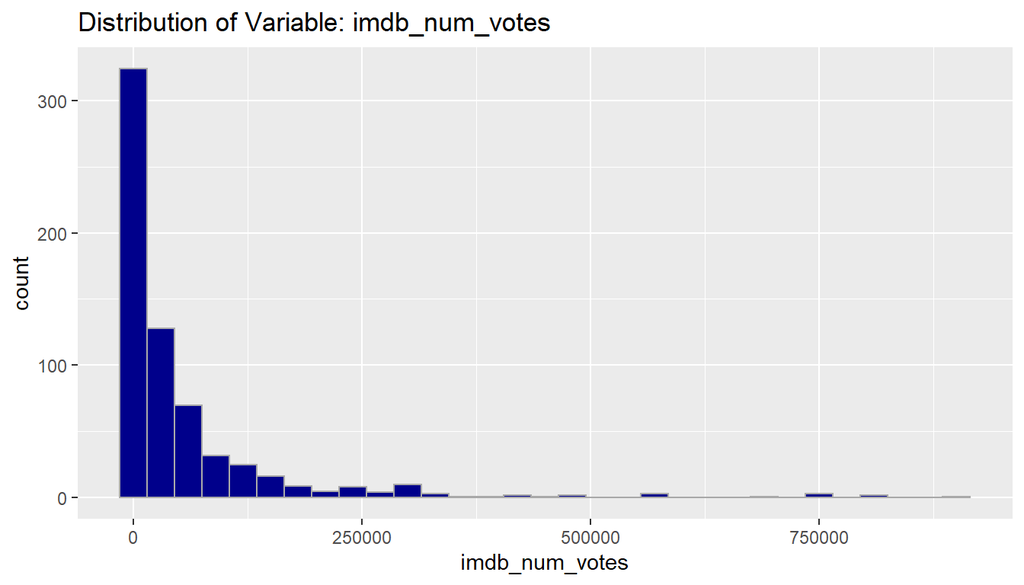

```r
ggplot(data = movies, aes (x = imdb_num_votes)) +
  geom_histogram(binwidth = 30000, color='darkgray', fill  = 'darkblue') +
  labs(title = "Distribution of Variable: imdb_num_votes" )
```

```r
summary(movies$imdb_num_votes)
```

```
##    Min. 1st Qu.  Median    Mean 3rd Qu.    Max.
##     180    4546   15116   57533   58301  893008
```

As can be seen from the above histogram, the data for imdb_num_votes is strongly right skewed. Since non-normal distributions (like the strongly skewed data above) can be problematic when is comes to making inferences about the population, it is sensible to transform this data. We will do this using a log transformation:

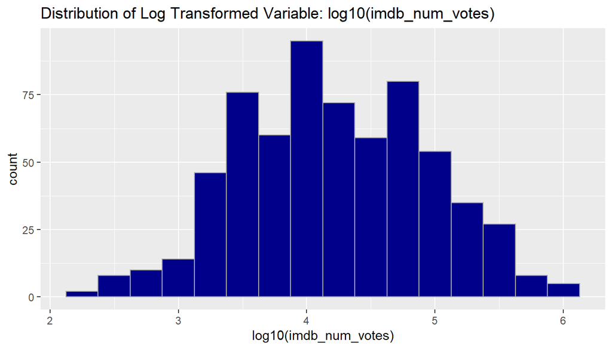

```r
ggplot(data = movies, aes (x = log10(imdb_num_votes))) +
  geom_histogram(binwidth = 0.25, color='darkgray', fill  = 'darkblue') +
  labs(title = "Distribution of Log Transformed Variable: log10(imdb_num_votes)" )
```

After the log transformation, the imdb_num_votes variable can now be seen to be nearly normal, and therefore suitable to use in the model.

The last distribution to look at is for the other numeric variable, runtime. This can be seen below:

[figure not shown]

```r
ggplot(data = movies, aes (x = runtime)) +
  geom_histogram(binwidth = 10, color='darkgray', fill  = 'darkblue') +
  labs(title = "Distribution of Variable: imdb_rating" )
```

```r
summary(movies$runtime)
```

```
##    Min. 1st Qu.  Median    Mean 3rd Qu.    Max.    NA's
##    39.0    92.0   103.0   105.8   115.8   267.0       1
```

This distribution can be seen to right skew. As we have a large sample size (n > 30), this skew should not affect any inferences made regarding the population.

For a linear regression model to be valid, the response and explanatory variables need to have a linear dependence. This can be checked using scatter plots as seen below:

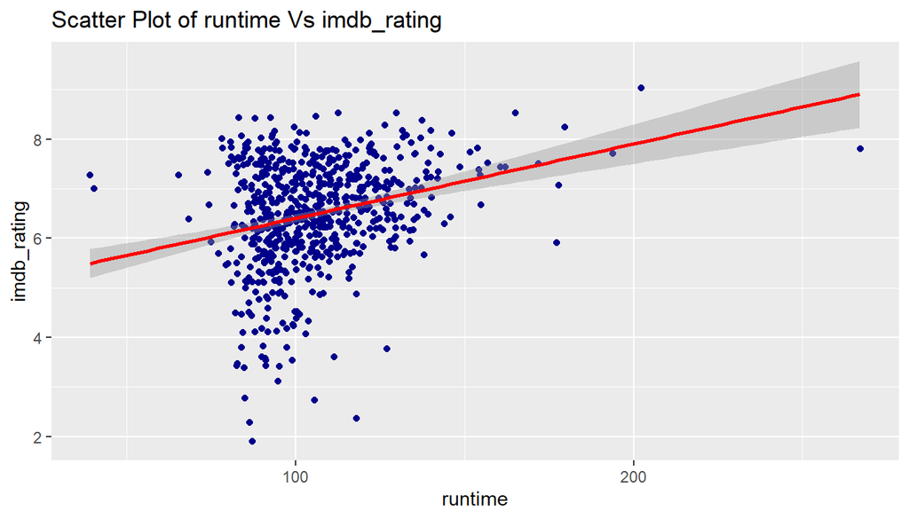

```r
ggplot(data = movies, aes (x = runtime, y = imdb_rating)) +
  geom_jitter(color = 'darkblue') +
  geom_smooth(method = 'lm', formula = y~x, color = 'red') +
  labs(title = "Scatter Plot of runtime Vs imdb_rating" )
```

[figure not shown]

```r
ggplot(data = movies, aes (x = log10(imdb_num_votes), y = imdb_rating)) +
  geom_point(color = 'darkblue') +
  geom_smooth(method = 'lm', formula = y~x, color = 'red') +
  labs(title = "Scatter Plot of runtime Vs log10(imdb_num_votes)" )
```

In this case, both of these explanatory variables appear to have a linear relationship with the response variable imdb_rating. It is noticeable, however, that the imdb_rating variable does not have a constant variation of data which may pose as a problem for the model and will be discussed further in the modelling section.

## Part 4: Modeling

The full model and summary statistics are given below:

```r
full_model = lm(imdb_rating ~ runtime +
                  log10(imdb_num_votes) +
                  title_type +
                  genre +
                  mpaa_rating +
                  best_pic_nom +
                  best_pic_win +
                  top200_box +
                  audience_score , data = movies)
summary(full_model)
```

```
##
## Call:
## lm(formula = imdb_rating ~ runtime + log10(imdb_num_votes) +
##     title_type + genre + mpaa_rating + best_pic_nom + best_pic_win +
##     top200_box + audience_score, data = movies)
##
## Residuals:
##      Min       1Q   Median       3Q      Max
## -2.75784 -0.18403  0.06506  0.27941  1.12737
##
## Coefficients:
##                                 Estimate Std. Error t value Pr(>|t|)
## (Intercept)                     3.187509   0.271904  11.723  < 2e-16 ***
## runtime                         0.004976   0.001168   4.261 2.34e-05 ***
## log10(imdb_num_votes)           0.166544   0.036074   4.617 4.73e-06 ***
## title_typeFeature Film         -0.424268   0.188215  -2.254 0.024531 *
## title_typeTV Movie             -0.582394   0.293413  -1.985 0.047593 *
## genreAnimation                 -0.477615   0.196167  -2.435 0.015181 *
## genreArt House & International  0.345997   0.154235   2.243 0.025226 *
## genreComedy                    -0.076547   0.084270  -0.908 0.364041
## genreDocumentary                0.306482   0.201169   1.524 0.128136
## genreDrama                      0.252813   0.074285   3.403 0.000708 ***
## genreHorror                     0.211436   0.125355   1.687 0.092158 .
## genreMusical & Performing Arts  0.177514   0.173600   1.023 0.306917
## genreMystery & Suspense         0.397680   0.092913   4.280 2.16e-05 ***
## genreOther                      0.159449   0.143320   1.113 0.266336
## genreScience Fiction & Fantasy -0.073025   0.178333  -0.409 0.682325
## mpaa_ratingNC-17                0.017920   0.379427   0.047 0.962346
## mpaa_ratingPG                  -0.244997   0.138314  -1.771 0.076994 .
## mpaa_ratingPG-13               -0.319289   0.143170  -2.230 0.026092 *
## mpaa_ratingR                   -0.206856   0.137958  -1.499 0.134272
## mpaa_ratingUnrated             -0.167853   0.158287  -1.060 0.289355
## best_pic_nomyes                 0.019774   0.129091   0.153 0.878305
## best_pic_winyes                 0.098580   0.218813   0.451 0.652489
## top200_boxyes                  -0.018566   0.137628  -0.135 0.892737
## audience_score                  0.040229   0.001239  32.468  < 2e-16 ***
## ---
## Signif. codes:  0 '***' 0.001 '**' 0.01 '*' 0.05 '.' 0.1 ' ' 1
##
## Residual standard error: 0.5003 on 626 degrees of freedom
##   (1 observation deleted due to missingness)
## Multiple R-squared:  0.7949, Adjusted R-squared:  0.7874
## F-statistic: 105.5 on 23 and 626 DF,  p-value: < 2.2e-16
```

```r
model_2 = lm(imdb_rating ~ runtime  +
               log10(imdb_num_votes)  +
               genre +
               audience_score , data = movies)
summary((model_2))
```

```
##
## Call:
## lm(formula = imdb_rating ~ runtime + log10(imdb_num_votes) +
##     genre + audience_score, data = movies)
##
## Residuals:
##      Min       1Q   Median       3Q      Max
## -2.75090 -0.17449  0.05751  0.29980  1.04646
##
## Coefficients:
##                                 Estimate Std. Error t value Pr(>|t|)
## (Intercept)                     2.606513   0.168855  15.436  < 2e-16 ***
## runtime                         0.004792   0.001128   4.249 2.46e-05 ***
## log10(imdb_num_votes)           0.140507   0.033627   4.178 3.35e-05 ***
## genreAnimation                 -0.339793   0.179865  -1.889  0.05932 .
## genreArt House & International  0.341029   0.151528   2.251  0.02475 *
## genreComedy                    -0.094089   0.083073  -1.133  0.25781
## genreDocumentary                0.688653   0.113635   6.060 2.33e-09 ***
## genreDrama                      0.234308   0.072043   3.252  0.00121 **
## genreHorror                     0.234588   0.122839   1.910  0.05662 .
## genreMusical & Performing Arts  0.287783   0.164726   1.747  0.08111 .
## genreMystery & Suspense         0.404617   0.090752   4.459 9.76e-06 ***
## genreOther                      0.129547   0.141883   0.913  0.36156
## genreScience Fiction & Fantasy -0.052739   0.178632  -0.295  0.76791
## audience_score                  0.041358   0.001185  34.887  < 2e-16 ***
## ---
## Signif. codes:  0 '***' 0.001 '**' 0.01 '*' 0.05 '.' 0.1 ' ' 1
##
## Residual standard error: 0.5019 on 636 degrees of freedom
##   (1 observation deleted due to missingness)
## Multiple R-squared:  0.7902, Adjusted R-squared:  0.7859
## F-statistic: 184.3 on 13 and 636 DF,  p-value: < 2.2e-16
```

For the model to provide valid results, there are certain conditions that need to be met. These are:

1. Linear relationships between (numerical) x and y
2. Nearly normal residuals with mean 0
3. Constant variability of residuals
4. Independent residuals

The first condition has already been verified by the previous scatter plots with the numerical variables. The condition for nearly normal residuals can be checked using histogram and/or Q-Q plot of the residuals:

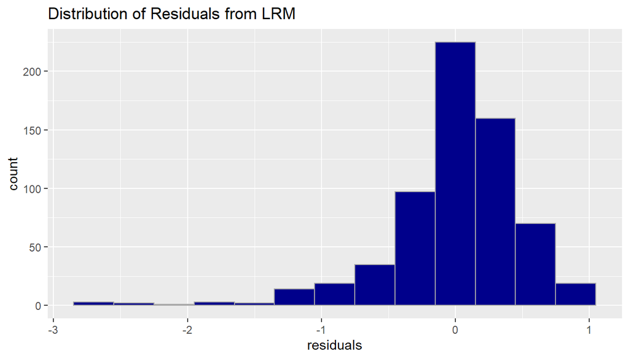

```r
ggplot(data = model_2, aes(x = model_2$residuals)) +
  geom_histogram(color = 'darkgray', fill = 'darkblue', binwidth = .3)  +
  labs(x = "residuals", title = "Distribution of Residuals from LRM" )
```

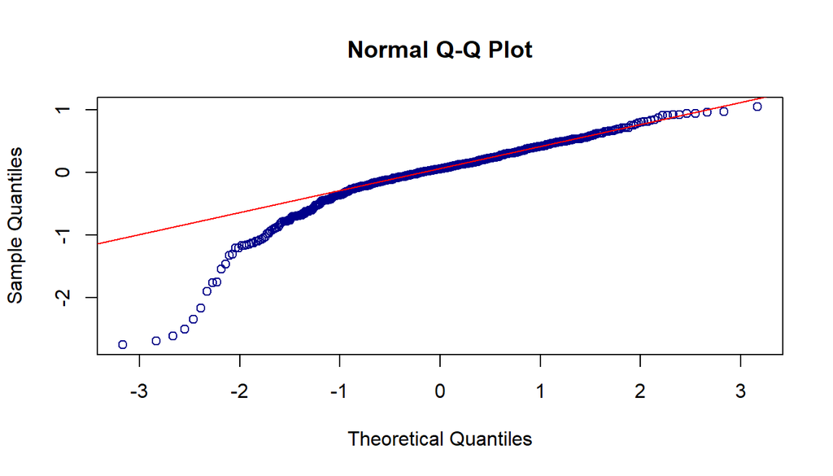

```r
qqnorm(model_2$residuals, col = 'darkblue')
qqline(model_2$residuals, col = 'red')
```

```r
summary(model_2$residuals)
```

```
##     Min.  1st Qu.   Median     Mean  3rd Qu.     Max.
## -2.75090 -0.17449  0.05751  0.00000  0.29980  1.04646
```

From the summary statistics the mean of the residuals can be seen to equal zero. However, the histogram shows that the residuals are somewhat left skewed, due to a small proportion of outliers. The Q-Q plot also indicates an almost normal distribution, with some deviation from normality occurring on the left hand side, indicating again that the data is left skewed. As both plots show a nearly normal distribution, with the skew that is occurs appearing to be for more extreme values, we can be satisfied condition 2 has been met.

The variability of residuals can be checked by plotting the residuals against the predicted values from the model as seen below:

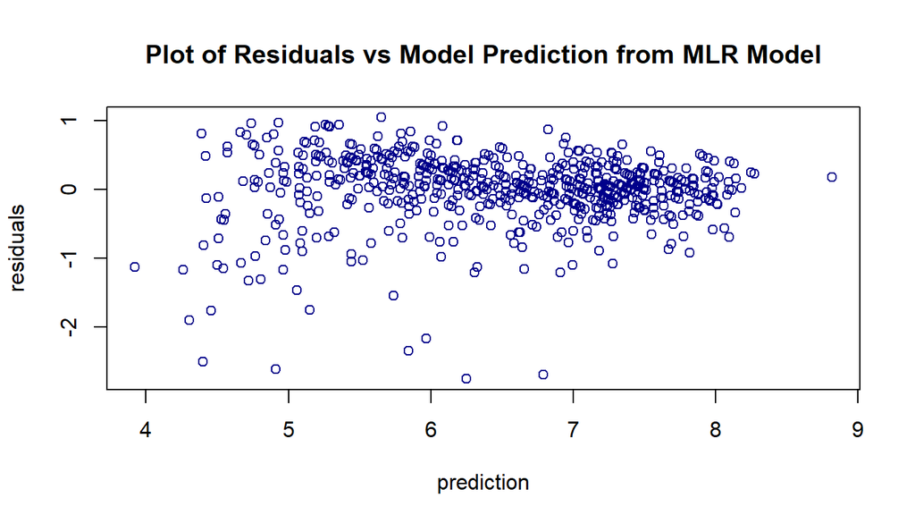

```r
plot(model_2$residuals ~ model_2$fitted,
     main = 'Plot of Residuals vs Model Prediction from MLR Model',
     xlab = 'prediction',
     ylab = 'residuals',
     col = 'darkblue')
```

It is quite clear from this plot that the variability of residuals is not constant. The implications of this are that the values for the standard error are not entirely accurate and could therefore affect the accuracy of confidence intervals and the outcome of hypothesis tests from the model. If the model was altered to take into account the non-constancy that is present, then this would resolve this issue, however, this is outwith the scope of this project.

To check if we have independent residuals (condition 4), we can plot the residuals as they appear in the data which would reveal any time series dependence:

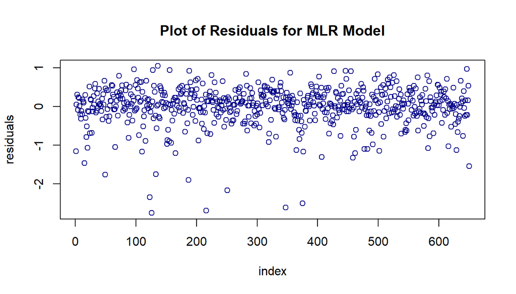

```r
plot(model_2$residuals,
     main = 'Plot of Residuals for MLR Model',
     xlab = 'index',
     ylab = 'residuals',
     col = 'darkblue')
```

As can be seen from this plot, the residuals are distributed randomly, and are, therefore, independent. This is to be expected since the movie data was sampled randomly.

## Part 5: Prediction

As mentioned previously, a 80% confidence interval will be used for the model prediction:

```r
arrival = data.frame(runtime = 116,
                     genre = 'Science Fiction & Fantasy' ,
                     imdb_num_votes = 554181,
                     audience_score = 82,
                     stringsAsFactors=FALSE)
predict(model_2,
        arrival,
        interval = "prediction",
        level = 0.8)
```

```
##        fit      lwr      upr
## 1 7.308038 6.626778 7.989298
```

## Part 6: Conclusion

In this instance, it is possible to check if the prediction of the model is correct or not. With the movie Arrival having a IMDB rating of 7.9, the prediction in this case was correct. Overall we can conclude that the explanatory variables explored during this project are significant predictors of IMdb rating, and can be used to predict them. There are a couple of points to note however. Firstly, the confidence level for the given interval may be lower than stated in reality due to the variability in the residuals. Secondly, the Adjusted $R^{2}$ value for the model was given to be 0.78. This means that approx. 22% of the variability of the data is not explained by the model.

Future research, and improvements to the model, could stem from learning how to transform the data appropriately so that the non-constancy of the data is negated in the model.